# More Seniment Analysis with R

Christina Garcia, Ph.D., and Christopher Prener, Ph.D.

November 29, 2017

## Introduction

This is an extra notebook associated with our seminar on sentiment analysis using `R`. This was given as part of the Digital Humanities’ Fall 2017 seminar series. This notebook shows how to import raw text files into `R` for use with `tidytext`. We also build off examples from Julia Silge and David Robinson’s book [*Tidy Text Mining with `R`*](http://tidytextmining.com).

## Dependencies

The following packages are needed for the following examples:

```r
library(dplyr)    # clean data
library(ggplot2)  # plotting data
library(stringr)  # work with strings
library(tidyr)    # clean data
library(tidytext) # text analysis
```

## Reading in Text Files

We can use the `read.delim()` function to import our `txt` file with Robert Frost’s “The Road Not Taken”:

```r
frostRoads <- read.delim("frostRoads.txt", header = FALSE, stringsAsFactors = FALSE)
```

## Cleaning and Analyzing Imported Data

We need to take some extra steps for cleaning the poem. First, it is imported as a data frame with a single variable named `V1`. We want to change that to `text` to match the code from [*Tidy Text Mining with `R`*](http://tidytextmining.com). We also want to cut out the line of code meant for managing chapters.

```r
frostRoads %>%
  rename(text = V1) %>%
  mutate(linenumber = row_number()) %>%
  ungroup() %>%
  unnest_tokens(word, text) -> tidyRoads
```

Our second block of code uses 2 lines instead of 80, since poems are quiet a bit shorter than novels. We also take out the reference to the `book` variable since that is not a relevant piece of data here.

```r
tidyRoads %>%
  inner_join(get_sentiments("bing")) %>%
  count(index = linenumber %/% 2, sentiment) %>%
  spread(sentiment, n, fill = 0) %>%
  mutate(sentiment = positive - negative) -> sentimentRoads
```

Our plot goes unchanged except for updating the object meant to be plotted.

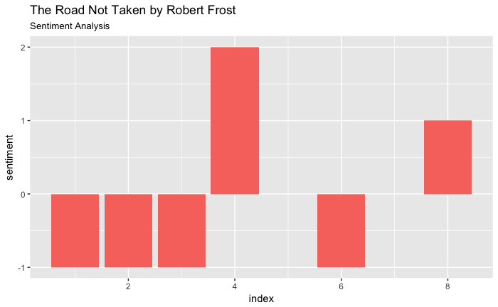

```r
ggplot(sentimentRoads, aes(x = index, y = sentiment)) +
  geom_col(fill = "#F8766D") +
  labs(
    title = "The Road Not Taken by Robert Frost",
    subtitle = "Sentiment Analysis")
```

Now you try to import and analyze another Frost poem, “Christmas Trees”.

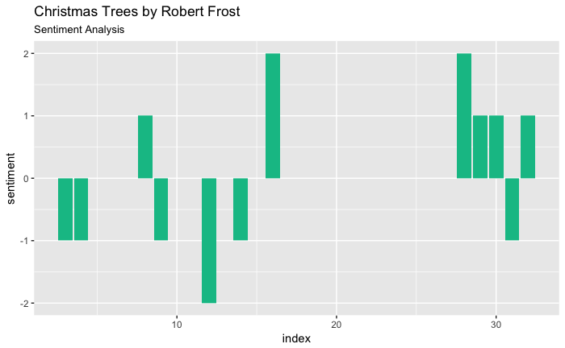

```r
frostXmas <- read.delim("frostXmas.txt", header = FALSE)
frostXmas %>%
  rename(text = V1) %>%
  mutate(text = as.character(text)) %>%
  mutate(linenumber = row_number()) %>%
  ungroup() %>%
  unnest_tokens(word, text) -> tidyXmas
tidyXmas %>%
  inner_join(get_sentiments("bing")) %>%
  count(index = linenumber %/% 2, sentiment) %>%
  spread(sentiment, n, fill = 0) %>%
  mutate(sentiment = positive - negative) -> sentimentXmas
ggplot(sentimentXmas, aes(x = index, y = sentiment)) +
  geom_col(fill = "#00C094") +
  labs(
    title = "Christmas Trees by Robert Frost",
    subtitle = "Sentiment Analysis")
```